# Analyzing data on the level of cognitive processes - ESCoP 2025

Gidon T. Frischkorn, Ruhi Bhanap, and Isabel Courage

# Solutions: Exercise 2: Hierarchical Models & Signal Detection Theory

```r
# empty environment
rm(list = ls())

# load libraries
library(brms)
library(tidyverse)
library(here)
```

## A - Fit Bayesian GLMs to the aggregated data

### 1) Load the **aggregated data** of experiment 2 of Williams et al. (2022).

This data set (filename: `exercise2_data_exp2_aggregated.txt`) contains aggregated performance indices from a Change Detection Task with Set Size 8 and a between subject manipulation `isAdaptive`. The manipulation entailed a prompt pushing participants to respond equally often with `same` and `different` to achieve a less biased response pattern.

```r
data_Williams2022_agg <- read.table(here("data","exercise2_data_exp2_aggregated.txt"))
head(data_Williams2022_agg)
```

```
##                id isAdaptive prop_correct        K    dprime       crit
## 1 0rjs8zk3f8a1c51         no    0.6666667 2.666667 0.9707840 0.49096234
## 2 1ntjctjk7c30h8e        yes    0.6400000 2.240000 0.7201744 0.09521913
## 3 1o34yg68q5f0082         no    0.7000000 3.200000 1.5997169 0.95082764
## 4 1p2orrruwowkyfk        yes    0.8600000 5.760000 2.2012469 0.19369466
## 5 1sj18cefeen6xdq         no    0.6266667 2.026667 0.7562075 0.56297078
## 6 1t9ccets6d4jmh1         no    0.7111111 3.377778 1.1321919 0.18377351
```

### 2) Fit Bayesian GLMs with either proportion correct, Cowan’s K or dprime as the dependent variable.

Use the `brm` function to specify that the dependent variable should vary as a function of the `isAdaptive` between-subject manipulation. Set appropriate priors for the `b` coefficients for the respective models. Use the `default_prior` function to get information which priors are set as a default by `brms`. Set the `sample_prior` option to `TRUE` when fitting the model. We need this option in order to perform hypothesis tests with the `hypothesis()` function later on.

```r
# check default priors
default_prior(prop_correct ~ 1 + isAdaptive, data = data_Williams2022_agg)
```

```
##                   prior     class          coef group resp dpar nlpar lb ub tag
##                  (flat)         b
##                  (flat)         b isAdaptiveyes
##  student_t(3, 0.7, 2.5) Intercept
##    student_t(3, 0, 2.5)     sigma                                      0
##        source
##       default
##  (vectorized)
##       default
##       default
```

```r
# change priors for parameters of class b
my_priors_pc <- prior(normal(0,0.25), class = b)

# specify the brmsformula
pc_formula <- bf(
  prop_correct ~ 1 + isAdaptive
)

# fit model
fit_pc <- brm(
  formula = pc_formula,
  data = data_Williams2022_agg,
  family = gaussian(),
  cores = 4,
  prior = my_priors_pc,
  sample_prior = TRUE,
  backend = "cmdstanr",
  refresh = 0,
  file = here("models", "model_sdt_glm_pc"),
  file_refit = "never"
)
```

```r
# check default priors
default_prior(K ~ isAdaptive, data = data_Williams2022_agg)
```

```
##                   prior     class          coef group resp dpar nlpar lb ub tag
##                  (flat)         b
##                  (flat)         b isAdaptiveyes
##  student_t(3, 2.8, 2.5) Intercept
##    student_t(3, 0, 2.5)     sigma                                      0
##        source
##       default
##  (vectorized)
##       default
##       default
```

```r
# change priors for parameters of class b
my_priors_CowansK <- prior(normal(0,1), class = b)

# specify the brmsformula
CowansK_formula <- bf(
  K ~ 1 + isAdaptive,
  sigma ~ 1 + isAdaptive
)

# fit model
fit_CowansK <- brm(
  formula = CowansK_formula,
  data = data_Williams2022_agg,
  family = gaussian(),
  cores = 4,
  prior = my_priors_CowansK,
  sample_prior = TRUE,
  backend = "cmdstanr",
  refresh = 0,
  file = here("models", "model_sdt_glm_k"),
  file_refit = "never"
)
```

```r
# check default priors
default_prior(dprime ~ isAdaptive, data = data_Williams2022_agg)
```

```
##                   prior     class          coef group resp dpar nlpar lb ub tag
##                  (flat)         b
##                  (flat)         b isAdaptiveyes
##  student_t(3, 1.1, 2.5) Intercept
##    student_t(3, 0, 2.5)     sigma                                      0
##        source
##       default
##  (vectorized)
##       default
##       default
```

```r
# change priors for parameters of class b
my_priors_dprime <- prior(normal(0,1), class = b)

# specify the brmsformula
dprime_formula <- bf(
  dprime ~ 1 + isAdaptive,
  sigma ~ 1 + isAdaptiv
)

# fit model
fit_dprime <- brm(
  formula = dprime_formula,
  data = data_Williams2022_agg,
  family = gaussian(),
  cores = 4,
  prior = my_priors_dprime,
  sample_prior = TRUE,
  backend = "cmdstanr",
  refresh = 0,
  file = here("models", "model_sdt_glm_dprime"),
  file_refit = "never"
)
```

### 3) Quantify the strength of evidence for or against an effect of the manipulation.

The `hypothesis` function allows to specify to-be-tested hypotheses for any GLM fitted with `brms`. For this you need to pass the `brmfit` object and a vector of character strings specifying the hypothesis you want to test. Usually you formulate the hypothesis in form of a null hypothesis. In order to use this function you need to set in your model the `sample_prior` option to `TRUE`.

```r
# proportion correct
hypothesis(fit_pc,
           "isAdaptiveyes = 0")
```

```
## Hypothesis Tests for class b:
##            Hypothesis Estimate Est.Error CI.Lower CI.Upper Evid.Ratio Post.Prob
## 1 (isAdaptiveyes) = 0     0.04      0.01     0.01     0.07       0.41      0.29
##   Star
## 1    *
## ---
## 'CI': 90%-CI for one-sided and 95%-CI for two-sided hypotheses.
## '*': For one-sided hypotheses, the posterior probability exceeds 95%;
## for two-sided hypotheses, the value tested against lies outside the 95%-CI.
## Posterior probabilities of point hypotheses assume equal prior probabilities.
```

```r
# Cowan's K
hypothesis(fit_CowansK,
           "isAdaptiveyes = 0")
```

```
## Hypothesis Tests for class b:
##            Hypothesis Estimate Est.Error CI.Lower CI.Upper Evid.Ratio Post.Prob
## 1 (isAdaptiveyes) = 0     0.62      0.23     0.16     1.07        0.1      0.09
##   Star
## 1    *
## ---
## 'CI': 90%-CI for one-sided and 95%-CI for two-sided hypotheses.
## '*': For one-sided hypotheses, the posterior probability exceeds 95%;
## for two-sided hypotheses, the value tested against lies outside the 95%-CI.
## Posterior probabilities of point hypotheses assume equal prior probabilities.
```

```r
# dPrime
hypothesis(fit_dprime,
           "isAdaptiveyes = 0")
```

```
## Hypothesis Tests for class b:
##            Hypothesis Estimate Est.Error CI.Lower CI.Upper Evid.Ratio Post.Prob
## 1 (isAdaptiveyes) = 0     0.08       0.1     -0.1     0.27       7.34      0.88
##   Star
## 1
## ---
## 'CI': 90%-CI for one-sided and 95%-CI for two-sided hypotheses.
## '*': For one-sided hypotheses, the posterior probability exceeds 95%;
## for two-sided hypotheses, the value tested against lies outside the 95%-CI.
## Posterior probabilities of point hypotheses assume equal prior probabilities.
```

## B - Fit Bayesian-hierarchical SDT model to the data

### 1) Load the **non-aggregated data** of experiment 2 of Williams et al. (2022).

```r
data_Williams2022 <- read.table(here("data","exercise2_data_exp2.txt"))
head(data_Williams2022)
```

```
##                id isAdaptive was_same_trial sum_saysame sum_correct n_trials
## 1 0rjs8zk3f8a1c51         no              0          37         188      225
## 2 0rjs8zk3f8a1c51         no              1         112         112      225
## 3 1ntjctjk7c30h8e        yes              1         136         136      225
## 4 1ntjctjk7c30h8e        yes              0          73         152      225
## 5 1o34yg68q5f0082         no              0           9         216      225
## 6 1o34yg68q5f0082         no              1          99          99      225
##   prop_correct
## 1    0.8355556
## 2    0.4977778
## 3    0.6044444
## 4    0.6755556
## 5    0.9600000
## 6    0.4400000
```

### 2) Specify the non-linear formula to fit an SDT model with this data.

Use the `brmsformula` function to specify the non-linear formula implementing an SDT model in a GLM. Predict both `dprime` and the `criterion` by the `isAdaptive` manipulation.

```r
sdt_formula <- bf(
  sum_saysame | trials(n_trials) ~ -crit + was_same_trial * dprime,
  dprime ~ 1 + isAdaptive + (1 | id),
  crit ~ 1 + isAdaptive + (1 | id),
  nl = TRUE
)
```

### 3) Fit the SDT model to the data.

Pass the `brmsformula` to the `brm` function and fit a binomial model with a **probit** link function.

Again consider specifying adequate priors for the parameters and plot the model predictions (hint: `conditional_effects()`). Use the `hypothesis` function to test on which parameters of the SDT model the `isAdaptive` manipulation has an effect.

Priors:

```r
# check default priors
default_prior(sdt_formula, data = data_Williams2022, family = binomial(link = "probit"))
```

```
##                 prior class          coef group resp dpar  nlpar lb ub tag
##                (flat)     b                                 crit
##                (flat)     b     Intercept                   crit
##                (flat)     b isAdaptiveyes                   crit
##  student_t(3, 0, 2.5)    sd                                 crit  0
##  student_t(3, 0, 2.5)    sd                  id             crit  0
##  student_t(3, 0, 2.5)    sd     Intercept    id             crit  0
##                (flat)     b                               dprime
##                (flat)     b     Intercept                 dprime
##                (flat)     b isAdaptiveyes                 dprime
##  student_t(3, 0, 2.5)    sd                               dprime  0
##  student_t(3, 0, 2.5)    sd                  id           dprime  0
##  student_t(3, 0, 2.5)    sd     Intercept    id           dprime  0
##        source
##       default
##  (vectorized)
##  (vectorized)
##       default
##  (vectorized)
##  (vectorized)
##       default
##  (vectorized)
##  (vectorized)
##       default
##  (vectorized)
##  (vectorized)
```

```r
# adapt priors
my_priors_sdt <- prior(normal(0,1), class = b, nlpar = crit) +
  prior(normal(0,1), class = b, nlpar = dprime)
```

Model:

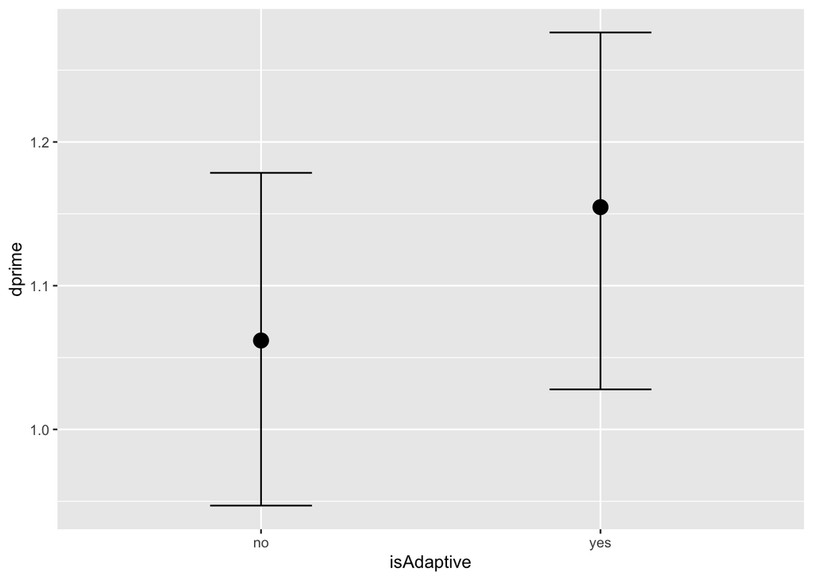

```r
# fit model
fit_sdt <- brm(
  formula = sdt_formula,
  data = data_Williams2022,
  family = binomial(link = "probit"),
  prior = my_priors_sdt,
  sample_prior = TRUE,
  cores = 4,
  refresh = 0,
  backend = "cmdstanr",
  file = here("models", "model_sdt"),
  file_refit = "never"
)

# plot model predicted effects
conditional_effects(fit_sdt, nlpar = "dprime", effects = "isAdaptive")
```

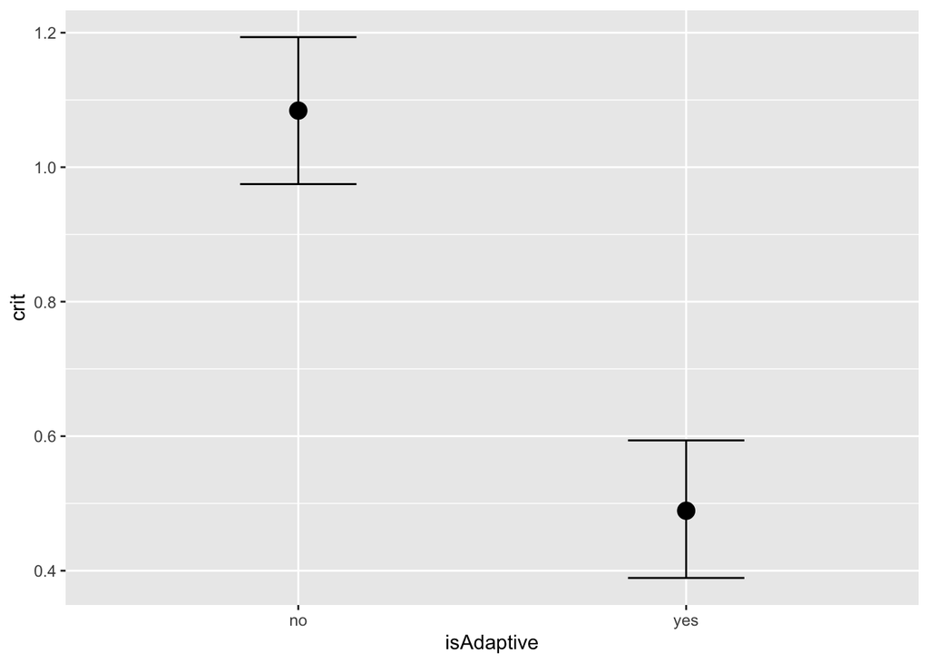

```r
conditional_effects(fit_sdt, nlpar = "crit", effects = "isAdaptive")
```

Hypotheses:

```r
# test if manipulation had effects on SDT parameters
hyp <- hypothesis(fit_sdt,
           c("dprime_isAdaptiveyes = 0",
             "crit_isAdaptiveyes = 0"))
hyp$hypothesis$Evid.Ratio
```

```
## [1] 6.448625e+00 1.399194e-19
```